# Reproducing treatment conditions in the election study

Laszlo

Thursday, September 15, 2016

The aim below is to replicate our analysis of treatment effects (on political interest, political efficacy, political knowledge & confidence) on the 2015 election study. I will recreate the treatment conditions as

1. the proportion of women running in respondents’ respective constituency, and
2. respondents’ awareness of women running in their constituency, and
3. (perhaps) the intensity of women’s campaign activity from the candidate study.

While number 1 above is meant to represent the fact that women are around, number 2 and 3 are proxies of women’s visibility, which would sharpen our argument in the exeriment results.

## Technical notes

I am loading directly the Stata file `'master survey data with constituency infor.dta'`. You can easily re-run the code below as is, just change the working directory at the very beginning. The only trick with the data set is that it needs to be saved in Stat 12 format, in order anything below to work.

Click `CODE` wherever it appears in the text to look through the withins. You can also download the full script here.

## Data overview

```r
setwd("C:/Users/lhorvath/Dropbox/women candidates")
library(data.table) # using data.table throughout to create easy summary tables
library(foreign) # to read stata 12

w <- as.data.table(read.dta("1211 master survey data with constituency infor.dta"))
w <- w[Wave1=="Took part in Wave 1",,] # I am taking wave 1 respondents for the time being. Without weight variables, it's unclear to me how to deal with multiple waves with topup respondents

# length(unique(w$ConstituencyName)) # number of constituencies
# length(unique(w$Region)) # number of regions
```

The data set consists of 3024 observations. Individuals are nested within 614 consistuencies.

First I looked how the number of respondents ranges within these constituencies,

```r
w[,.N,by=ConstituencyName][(order(N))] #counts rows by constituencies + orders them
```

```
##                      ConstituencyName  N
##   1:                         Aberavon  1
##   2:                        Aberconwy  1
##   3:            Bethnal Green and Bow  1
##   4:           Birmingham, Hodge Hill  1
##   5:             Birmingham, Ladywood  1
##  ---
## 610:                   North Somerset 14
## 611:                    South Norfolk 14
## 612:                       East Devon 15
## 613:                        Wakefield 16
## 614: Cities of London and Westminster 40
```

which is 1 to 40, and the number of constituencies with less than 5 respondents:

```r
w[,.N,by=ConstituencyName][N<5,,][order(N)] # after making the summary table, prints only those less than 5 + orders
```

```
##              ConstituencyName N
##   1:                 Aberavon 1
##   2:                Aberconwy 1
##   3:    Bethnal Green and Bow 1
##   4:   Birmingham, Hodge Hill 1
##   5:     Birmingham, Ladywood 1
##  ---
## 303: Wolverhampton South East 4
## 304: Worsley and Eccles South 4
## 305:                  Wrexham 4
## 306:              Wyre Forest 4
## 307:                 Ynys Môn 4
```

which is a good half of our constituencies. (I’ll think about this later.) Below I will report whether constituency size (=sampled respondents) is related to the treatment variable, which would perhaps be a bigger problem.

### Treatment variable 1.

In this data set, 7 parties may have campaigned with a woman— I don’t know what happens with independent candidates? I cannot seem to find a variable for that.

For instance, below is a list of men only constituencies (i.e. all parties, if ran at all, had a male candidate):

```r
# I think the party dummies were coded incorrectly: NA indicates that party did not run rather than we don't know it ran with a man or a woman?

w$con <- w$Conservative #making copies of the old variables
w$l <- w$Labour
w$li <- w$LibDem
w$g <- w$Green
w$ukip <- w$UKIP
w$snp <- w$SNP
w$pc <- w$PlaidCymru

pnames <- c("con","l","li","g","ukip","snp","pc")
w[, pnames] <- lapply(w[,pnames,with=FALSE],function(x)ifelse(is.na(x),-1,x)) # coding -1 if party did not run...:

w[con!=1 & l!=1 & li!=1 & g!=1 & ukip!=1 & snp!=1 & pc!=1, #...because the case selection would not have worked with NA's
  .N,
  by=list(ConstituencyName)] # 'congratulations you have an all male panel'
```

```
##             ConstituencyName N
##   1:               Aldershot 3
##   2:                   Angus 6
##   3:               Aylesbury 3
##   4:      Barrow and Furness 5
##   5: Basildon and Billericay 8
##  ---
## 125:    Wentworth and Dearne 3
## 126:       Weston-Super-Mare 4
## 127:                  Witney 1
## 128:               Wokingham 7
## 129:                 Wycombe 5
```

thus in a fifth of all constituencies, parties ran with only men.

The output below shows the number of women candidates by the number of constituncies. Most of them had at least one woman running, and we have very few with 3 or 4 women.

```r
# creating the treatment variable in terms of # of women running.

PNAMES <- c("Conservative","Labour","LibDem","Green","UKIP","SNP","PlaidCymru")
w$women.count <- apply(w[,PNAMES,with=FALSE], 1, function(x) sum(x,na.rm=TRUE)) #sums up the 1's

ttable <- w[,.(count=length(unique(ConstituencyName))),by=list(women.count)][order(women.count)] #number of constituencies given # of women candidates
names(ttable) <- c("# of women candidates","# of constituencies")
ttable
```

```
##    # of women candidates # of constituencies
## 1:                     0                 129
## 2:                     1                 235
## 3:                     2                 177
## 4:                     3                  58
## 5:                     4                  15
```

This, in itself, is not yet our treatment variable. In the experiment, we distinguished between token, critical mass, and parity presence. In the next step I will get at this ‘relative’ variable as follows:

If the data is correct about no independent candidates, the number of candidates per constituency ranges between:

```r
candidate.count <- apply(w[,PNAMES,with=FALSE],1,function(x) is.na(x)) # logical function, will be TRUE if party wasn't present with a candidate
candidate.count <- t(candidate.count) # reshape so that rows indicate observations
range(apply(candidate.count,1,function(x) sum(x=="FALSE"))) #counts the FALSE's = number of candidates in the constituency
```

```
## [1] 2 6
```

Thus in each constituency, we need to look at the number of women over the number of candidates. The observed proportions are:

```r
w$candidate.count <- apply(candidate.count,1,function(x) sum(x=="FALSE"))
w[,.(`N(constituencies)`=length(unique(ConstituencyName))),by=.(prop = round((w$women.count / w$candidate.count),digits=2))][order(prop)]
```

```
##     prop N(constituencies)
##  1: 0.00               129
##  2: 0.17                13
##  3: 0.20               209
##  4: 0.25                13
##  5: 0.33                22
##  6: 0.40               145
##  7: 0.50                17
##  8: 0.60                48
##  9: 0.67                 2
## 10: 0.75                 3
## 11: 0.80                13
```

```r
w$treat <- NA
w$women.prop <- round((w$women.count / w$candidate.count),digits=2)
w$treat[w$women.prop==0] <- "men only"
w$treat[w$women.prop>0 & w$women.prop<0.33] <- "token"
w$treat[w$women.prop>=0.33 & w$women.prop<0.5] <- "cmass"
w$treat[w$women.prop==0.5] <- "parity"
w$treat[w$women.prop>0.5] <- "w.majority"
w$treat <- factor(w$treat, levels=c("men only","token","cmass","parity","w.majority"))
w[,.(`N(constituencies)`=length(unique(ConstituencyName)),`N(respondents)`=.N),by=.(treatment = treat)][order(treatment)]
```

```
##     treatment N(constituencies) N(respondents)
## 1:   men only               129            626
## 2:      token               235           1178
## 3:      cmass               167            809
## 4:     parity                17             80
## 5: w.majority                66            331
```

We’ll look at treatment effects both on a (quasi-)continuous scale, in terms of the observed proportions, and across these categories as well.

### Treatment variable 2.

The next measurement option is to look at whether respondents were aware that women were (or weren’t) present in their constituency. We will pass this as a proxy for women’s visibility in the campaign.

Frankly I am not yet sure how do go about this. Below is a distribution of responses to this question, per treatment group:

```r
#Q29B Is a woman standing in your local constituency.

w$woman.know <- w$Q29b
levels(w$woman.know) <- c("1","0.1","0",NA) # I'm being creative here. I don't know yet what to do with the certain 'no' answer.
w$woman.know <- as.numeric(paste(w$woman.know))

w$wknow.proxy <- 0
w$wknow.proxy[w$woman.know > 0 & w$women.count > 0] <- 1 # that's 1 if (1) there was a woman running nad (2) they knew about it
w$wknow.proxy[w$woman.know == 0.1 & w$women.count == 0] <- 1 # that's if there were no women and they knew about it

w[,.N,by=list(Q29b,treat)][order(treat,Q29b)]
```

```
##           Q29b      treat   N
##  1:        Yes   men only 178
##  2:         No   men only 302
##  3: Don't know   men only 146
##  4:        Yes      token 658
##  5:         No      token 324
##  6: Don't know      token 196
##  7:        Yes      cmass 560
##  8:         No      cmass 107
##  9: Don't know      cmass 142
## 10:        Yes     parity  68
## 11:         No     parity   3
## 12: Don't know     parity   9
## 13:        Yes w.majority 268
## 14:         No w.majority  27
## 15: Don't know w.majority  36
```

```r
w[,.N,by=list(wknow.proxy,treat)][order(treat)]
```

```
##     wknow.proxy      treat   N
##  1:           1   men only 302
##  2:           0   men only 324
##  3:           1      token 982
##  4:           0      token 196
##  5:           1      cmass 667
##  6:           0      cmass 142
##  7:           1     parity  71
##  8:           0     parity   9
##  9:           1 w.majority 295
## 10:           0 w.majority  36
```

At the end of the day, the proxy variable should give (I thought) additional information about treatment effects, something like a treatment complicance check. But I am not sure how to put that in practice.

Perhaps examine the odds of a correct answer per category? Without controlling for demographics & extra information (which we did in the experiment), these odds are:

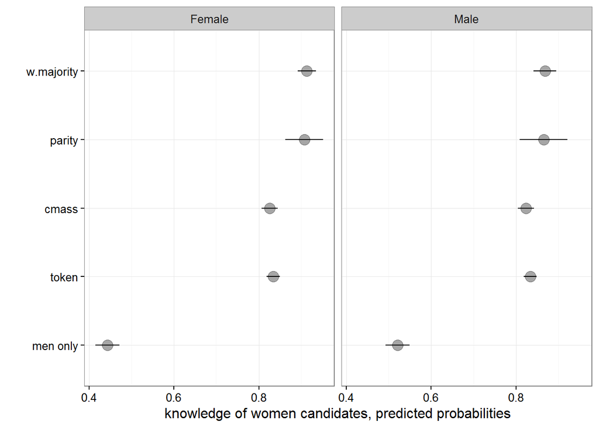

```r
library(stats)
wknow.odds <- glm(wknow.proxy ~ treat*QGENDER, data=w, family="binomial")
nwd <- data.frame(treat = rep(levels(w$treat),2), QGENDER = rep(levels(w$QGENDER),each=5))
nwd <- cbind(nwd, predict(wknow.odds, newdata=nwd,type="response",se.fit=TRUE))

library(ggplot2)
wknow.p <-
  ggplot(data = nwd,aes(x = treat, y = fit, ymin = fit-se.fit, ymax = fit+se.fit)) +
  geom_point(alpha=0.35,size=4) +
  geom_errorbar(width=0) +
  #geom_hline(aes(yintercept=0), linetype = 2, colour = "slateblue1") +
  ylab("knowledge of women candidates, predicted probabilities") +
  xlab("") +
  scale_x_discrete(limits=c("men only","token","cmass","parity","w.majority")) +
  coord_flip() +
  theme_bw()
wknow.p + facet_grid(. ~ QGENDER)
```

The plot above says that correct answers are least likely in the men only category, and most likely in the parity and w.majority conditions. For women, there some minor variation between parity/w.majority vs cmass and token categories.

But really this just shows that the baseline expectation of people is that there are women as running candidates. Their expectation are met in those constituencies where there are women.